# Data Analysis on Predict test scores of students

### Data loading

```r
df = read.csv('test_scores.csv')
head(df)
```

```
##   school school_setting school_type classroom teaching_method n_student
## 1  ANKYI          Urban  Non-public       6OL        Standard        20
## 2  ANKYI          Urban  Non-public       6OL        Standard        20
## 3  ANKYI          Urban  Non-public       6OL        Standard        20
## 4  ANKYI          Urban  Non-public       6OL        Standard        20
## 5  ANKYI          Urban  Non-public       6OL        Standard        20
## 6  ANKYI          Urban  Non-public       6OL        Standard        20
##   student_id gender            lunch pretest posttest
## 1      2FHT3 Female Does not qualify      62       72
## 2      3JIVH Female Does not qualify      66       79
## 3      3XOWE   Male Does not qualify      64       76
## 4      556O0 Female Does not qualify      61       77
## 5      74LOE   Male Does not qualify      64       76
## 6      7YZO8 Female Does not qualify      66       74
```

### The type of object can be ascertained using the class() command

```r
class(df)
```

```
## [1] "data.frame"
```

```r
class(df$posttest)
```

```
## [1] "numeric"
```

```r
class(dimnames(df))
```

```
## [1] "list"
```

### Shows the top of the data object and by default shows the first six rows:

```r
head(df)
```

```
##   school school_setting school_type classroom teaching_method n_student
## 1  ANKYI          Urban  Non-public       6OL        Standard        20
## 2  ANKYI          Urban  Non-public       6OL        Standard        20
## 3  ANKYI          Urban  Non-public       6OL        Standard        20
## 4  ANKYI          Urban  Non-public       6OL        Standard        20
## 5  ANKYI          Urban  Non-public       6OL        Standard        20
## 6  ANKYI          Urban  Non-public       6OL        Standard        20
##   student_id gender            lunch pretest posttest
## 1      2FHT3 Female Does not qualify      62       72
## 2      3JIVH Female Does not qualify      66       79
## 3      3XOWE   Male Does not qualify      64       76
## 4      556O0 Female Does not qualify      61       77
## 5      74LOE   Male Does not qualify      64       76
## 6      7YZO8 Female Does not qualify      66       74
```

### Can elect to show a different number of rows using the n = instruction like so:

```r
head(df, n=3)
```

```
##   school school_setting school_type classroom teaching_method n_student
## 1  ANKYI          Urban  Non-public       6OL        Standard        20
## 2  ANKYI          Urban  Non-public       6OL        Standard        20
## 3  ANKYI          Urban  Non-public       6OL        Standard        20
##   student_id gender            lunch pretest posttest
## 1      2FHT3 Female Does not qualify      62       72
## 2      3JIVH Female Does not qualify      66       79
## 3      3XOWE   Male Does not qualify      64       76
```

### can also display the bottom of the data using the tail() command default shows the last six rows:

```r
tail(df)
```

```
##      school school_setting school_type classroom teaching_method n_student
## 2128  ZOWMK          Urban      Public       ZBH        Standard        30
## 2129  ZOWMK          Urban      Public       ZBH        Standard        30
## 2130  ZOWMK          Urban      Public       ZBH        Standard        30
## 2131  ZOWMK          Urban      Public       ZBH        Standard        30
## 2132  ZOWMK          Urban      Public       ZBH        Standard        30
## 2133  ZOWMK          Urban      Public       ZBH        Standard        30
##      student_id gender                            lunch pretest posttest
## 2128      S4I5S   Male Qualifies for reduced/free lunch      39       50
## 2129      T8LSK Female                 Does not qualify      39       55
## 2130      VNP26 Female Qualifies for reduced/free lunch      38       46
## 2131      YDR1Z Female Qualifies for reduced/free lunch      45       51
## 2132      YUEIH   Male Qualifies for reduced/free lunch      46       53
## 2133      ZVCQ8   Male Qualifies for reduced/free lunch      41       48
```

### Can elect to show a different number of rows using the n = instruction like so:

```r
tail(df, n=3)
```

```
##      school school_setting school_type classroom teaching_method n_student
## 2131  ZOWMK          Urban      Public       ZBH        Standard        30
## 2132  ZOWMK          Urban      Public       ZBH        Standard        30
## 2133  ZOWMK          Urban      Public       ZBH        Standard        30
##      student_id gender                            lunch pretest posttest
## 2131      YDR1Z Female Qualifies for reduced/free lunch      45       51
## 2132      YUEIH   Male Qualifies for reduced/free lunch      46       53
## 2133      ZVCQ8   Male Qualifies for reduced/free lunch      41       48
```

### To get information about an Data frame and particular columns:

```r
summary(df)
```

```
##     school          school_setting     school_type         classroom
##  Length:2133        Length:2133        Length:2133        Length:2133
##  Class :character   Class :character   Class :character   Class :character
##  Mode  :character   Mode  :character   Mode  :character   Mode  :character
##
##
##
##  teaching_method      n_student     student_id           gender
##  Length:2133        Min.   :14.0   Length:2133        Length:2133
##  Class :character   1st Qu.:20.0   Class :character   Class :character
##  Mode  :character   Median :22.0   Mode  :character   Mode  :character
##                     Mean   :22.8
##                     3rd Qu.:27.0
##                     Max.   :31.0
##     lunch              pretest         posttest
##  Length:2133        Min.   :22.00   Min.   : 32.0
##  Class :character   1st Qu.:44.00   1st Qu.: 56.0
##  Mode  :character   Median :56.00   Median : 68.0
##                     Mean   :54.96   Mean   : 67.1
##                     3rd Qu.:65.00   3rd Qu.: 77.0
##                     Max.   :93.00   Max.   :100.0
```

```r
summary(df$posttest)
```

```
##    Min. 1st Qu.  Median    Mean 3rd Qu.    Max.
##    32.0    56.0    68.0    67.1    77.0   100.0
```

```r
mean(df$posttest)
```

```
## [1] 67.1022
```

```r
median(df$posttest)
```

```
## [1] 68
```

### Shows the median absolute deviation

```r
mad(df$posttest)
```

```
## [1] 16.3086
```

```r
mode(df$posttest)
```

```
## [1] "numeric"
```

```r
var(df$posttest)
```

```
## [1] 195.6303
```

```r
sd(df$posttest)
```

```
## [1] 13.98679
```

```r
quantile(df$posttest)
```

```
##   0%  25%  50%  75% 100%
##   32   56   68   77  100
```

### Returns Tukey’s five number summary (minimum, lower-hinge, median, upper-hinge, maximum) for the input data.

```r
fivenum(df$posttest)
```

```
## [1]  32  56  68  77 100
```

### F Test to Compare Two Variances

```r
var.test(df$posttest, df$pretest)
```

```
##
##  F test to compare two variances
##
## data:  df$posttest and df$pretest
## F = 1.0635, num df = 2132, denom df = 2132, p-value = 0.1556
## alternative hypothesis: true ratio of variances is not equal to 1
## 95 percent confidence interval:
##  0.9768739 1.1577039
## sample estimates:
## ratio of variances
##           1.063452
```

### str() command is useful to see the object structure

```r
str(df)
```

```
## 'data.frame':    2133 obs. of  11 variables:
##  $ school         : chr  "ANKYI" "ANKYI" "ANKYI" "ANKYI" ...
##  $ school_setting : chr  "Urban" "Urban" "Urban" "Urban" ...
##  $ school_type    : chr  "Non-public" "Non-public" "Non-public" "Non-public" ...
##  $ classroom      : chr  "6OL" "6OL" "6OL" "6OL" ...
##  $ teaching_method: chr  "Standard" "Standard" "Standard" "Standard" ...
##  $ n_student      : num  20 20 20 20 20 20 20 20 20 20 ...
##  $ student_id     : chr  "2FHT3" "3JIVH" "3XOWE" "556O0" ...
##  $ gender         : chr  "Female" "Female" "Male" "Female" ...
##  $ lunch          : chr  "Does not qualify" "Does not qualify" "Does not qualify" "Does not qualify" ...
##  $ pretest        : num  62 66 64 61 64 66 63 63 64 61 ...
##  $ posttest       : num  72 79 76 77 76 74 75 72 77 72 ...
```

### structure returns the given object with further attributes set

```r
head(structure(df))
```

```
##   school school_setting school_type classroom teaching_method n_student
## 1  ANKYI          Urban  Non-public       6OL        Standard        20
## 2  ANKYI          Urban  Non-public       6OL        Standard        20
## 3  ANKYI          Urban  Non-public       6OL        Standard        20
## 4  ANKYI          Urban  Non-public       6OL        Standard        20
## 5  ANKYI          Urban  Non-public       6OL        Standard        20
## 6  ANKYI          Urban  Non-public       6OL        Standard        20
##   student_id gender            lunch pretest posttest
## 1      2FHT3 Female Does not qualify      62       72
## 2      3JIVH Female Does not qualify      66       79
## 3      3XOWE   Male Does not qualify      64       76
## 4      556O0 Female Does not qualify      61       77
## 5      74LOE   Male Does not qualify      64       76
## 6      7YZO8 Female Does not qualify      66       74
```

### can also look at all the named objects you have at once using the ls.str() command

```r
ls.str(df)
```

```
## classroom :  chr [1:2133] "6OL" "6OL" "6OL" "6OL" "6OL" "6OL" "6OL" "6OL" "6OL" "6OL" ...
## gender :  chr [1:2133] "Female" "Female" "Male" "Female" "Male" "Female" "Male" ...
## lunch :  chr [1:2133] "Does not qualify" "Does not qualify" "Does not qualify" ...
## n_student :  num [1:2133] 20 20 20 20 20 20 20 20 20 20 ...
## posttest :  num [1:2133] 72 79 76 77 76 74 75 72 77 72 ...
## pretest :  num [1:2133] 62 66 64 61 64 66 63 63 64 61 ...
## school :  chr [1:2133] "ANKYI" "ANKYI" "ANKYI" "ANKYI" "ANKYI" "ANKYI" "ANKYI" ...
## school_setting :  chr [1:2133] "Urban" "Urban" "Urban" "Urban" "Urban" "Urban" "Urban" ...
## school_type :  chr [1:2133] "Non-public" "Non-public" "Non-public" "Non-public" ...
## student_id :  chr [1:2133] "2FHT3" "3JIVH" "3XOWE" "556O0" "74LOE" "7YZO8" "9KMZD" ...
## teaching_method :  chr [1:2133] "Standard" "Standard" "Standard" "Standard" "Standard" ...
```

### can use the pattern = instruction to narrow down your focus

```r
ls.str(pattern = 'df')
```

```
## df : 'data.frame':   2133 obs. of  11 variables:
##  $ school         : chr  "ANKYI" "ANKYI" "ANKYI" "ANKYI" ...
##  $ school_setting : chr  "Urban" "Urban" "Urban" "Urban" ...
##  $ school_type    : chr  "Non-public" "Non-public" "Non-public" "Non-public" ...
##  $ classroom      : chr  "6OL" "6OL" "6OL" "6OL" ...
##  $ teaching_method: chr  "Standard" "Standard" "Standard" "Standard" ...
##  $ n_student      : num  20 20 20 20 20 20 20 20 20 20 ...
##  $ student_id     : chr  "2FHT3" "3JIVH" "3XOWE" "556O0" ...
##  $ gender         : chr  "Female" "Female" "Male" "Female" ...
##  $ lunch          : chr  "Does not qualify" "Does not qualify" "Does not qualify" "Does not qualify" ...
##  $ pretest        : num  62 66 64 61 64 66 63 63 64 61 ...
##  $ posttest       : num  72 79 76 77 76 74 75 72 77 72 ...
```

### The most basic command that enables the viewing of column or row is:

```r
names(df)
```

```
##  [1] "school"          "school_setting"  "school_type"     "classroom"
##  [5] "teaching_method" "n_student"       "student_id"      "gender"
##  [9] "lunch"           "pretest"         "posttest"
```

```r
row.names(df)
```

```
##    [1] "1"    "2"    "3"    "4"    "5"    "6"    "7"    "8"    "9"    "10"
##   [11] "11"   "12"   "13"   "14"   "15"   "16"   "17"   "18"   "19"   "20"
##   [21] "21"   "22"   "23"   "24"   "25"   "26"   "27"   "28"   "29"   "30"
##   [31] "31"   "32"   "33"   "34"   "35"   "36"   "37"   "38"   "39"   "40"
##   [41] "41"   "42"   "43"   "44"   "45"   "46"   "47"   "48"   "49"   "50"
##   [51] "51"   "52"   "53"   "54"   "55"   "56"   "57"   "58"   "59"   "60"
##   [61] "61"   "62"   "63"   "64"   "65"   "66"   "67"   "68"   "69"   "70"
##   [71] "71"   "72"   "73"   "74"   "75"   "76"   "77"   "78"   "79"   "80"
##   [81] "81"   "82"   "83"   "84"   "85"   "86"   "87"   "88"   "89"   "90"
##   [91] "91"   "92"   "93"   "94"   "95"   "96"   "97"   "98"   "99"   "100"
##  [101] "101"  "102"  "103"  "104"  "105"  "106"  "107"  "108"  "109"  "110"
##  [111] "111"  "112"  "113"  "114"  "115"  "116"  "117"  "118"  "119"  "120"
##  [121] "121"  "122"  "123"  "124"  "125"  "126"  "127"  "128"  "129"  "130"
##  [131] "131"  "132"  "133"  "134"  "135"  "136"  "137"  "138"  "139"  "140"
##  [141] "141"  "142"  "143"  "144"  "145"  "146"  "147"  "148"  "149"  "150"
```

[output cut: 199 more lines]

```r
colnames(df)
```

```
##  [1] "school"          "school_setting"  "school_type"     "classroom"
##  [5] "teaching_method" "n_student"       "student_id"      "gender"
##  [9] "lunch"           "pretest"         "posttest"
```

### dimnames(): this looks at both the row and column names at the same time:

```r
dimnames(df)
```

```
## [[1]]
##    [1] "1"    "2"    "3"    "4"    "5"    "6"    "7"    "8"    "9"    "10"
##   [11] "11"   "12"   "13"   "14"   "15"   "16"   "17"   "18"   "19"   "20"
##   [21] "21"   "22"   "23"   "24"   "25"   "26"   "27"   "28"   "29"   "30"
##   [31] "31"   "32"   "33"   "34"   "35"   "36"   "37"   "38"   "39"   "40"
##   [41] "41"   "42"   "43"   "44"   "45"   "46"   "47"   "48"   "49"   "50"
##   [51] "51"   "52"   "53"   "54"   "55"   "56"   "57"   "58"   "59"   "60"
##   [61] "61"   "62"   "63"   "64"   "65"   "66"   "67"   "68"   "69"   "70"
##   [71] "71"   "72"   "73"   "74"   "75"   "76"   "77"   "78"   "79"   "80"
##   [81] "81"   "82"   "83"   "84"   "85"   "86"   "87"   "88"   "89"   "90"
##   [91] "91"   "92"   "93"   "94"   "95"   "96"   "97"   "98"   "99"   "100"
##  [101] "101"  "102"  "103"  "104"  "105"  "106"  "107"  "108"  "109"  "110"
##  [111] "111"  "112"  "113"  "114"  "115"  "116"  "117"  "118"  "119"  "120"
##  [121] "121"  "122"  "123"  "124"  "125"  "126"  "127"  "128"  "129"  "130"
##  [131] "131"  "132"  "133"  "134"  "135"  "136"  "137"  "138"  "139"  "140"
```

[output cut: 205 more lines]

### length() command used to determine the number of items in an object

```r
length(df)
```

```
## [1] 11
```

### To extract a particular column and particular row values

```r
head(df$posttest)
```

```
## [1] 72 79 76 77 76 74
```

```r
df$posttest[3]
```

```
## [1] 76
```

```r
df$posttest[1:5]
```

```
## [1] 72 79 76 77 76
```

```r
tdf = attach(df)
tdf
```

```
## <environment: 0x00000000133a71c8>
## attr(,"name")
## [1] "df"
```

### The max() and min() commands display the largest and smallest values in a numeric object

```r
max(df$posttest)
```

```
## [1] 100
```

```r
max(df$pretest)
```

```
## [1] 93
```

```r
min(df$posttest)
```

```
## [1] 32
```

```r
min(df$pretest)
```

```
## [1] 22
```

```r
head(stack(df))
```

```
##   values    ind
## 1  ANKYI school
## 2  ANKYI school
## 3  ANKYI school
## 4  ANKYI school
## 5  ANKYI school
## 6  ANKYI school
```

### Sorting default is ascending order

```r
head(sort(df$posttest))
```

```
## [1] 32 34 35 36 36 37
```

```r
head(sort(df$pretest))
```

```
## [1] 22 23 25 26 26 26
```

### can get an index using the order() command. This uses the same instructions as the sort() command, but tells you the position of each item along the vector:

```r
head(order(df$posttest))
```

```
## [1]  741  752  747  729 1011 1013
```

### The rank() command gives the rank number like order() in a slightly different manner when the values are same the ranks are shared between them which is not in order()

```r
head(rank(df$posttest), n=10)
```

```
##  [1] 1319.5 1685.0 1530.5 1579.0 1530.5 1432.0 1483.0 1319.5 1579.0 1319.5
```

### Displaying selected rows & columns

```r
df[3,3]
```

```
## [1] "Non-public"
```

```r
df[3, 1:5]
```

```
##   school school_setting school_type classroom teaching_method
## 3  ANKYI          Urban  Non-public       6OL        Standard
```

```r
df[c(1,455,1000),]
```

```
##      school school_setting school_type classroom teaching_method n_student
## 1     ANKYI          Urban  Non-public       6OL        Standard        20
## 455   FBUMG          Rural  Non-public       197    Experimental        14
## 1000  KZKKE          Rural      Public       2BR        Standard        20
##      student_id gender                            lunch pretest posttest
## 1         2FHT3 Female                 Does not qualify      62       72
## 455       3234W   Male                 Does not qualify      63       78
## 1000      OQIGJ Female Qualifies for reduced/free lunch      50       55
```

```r
df[c(511,652,121), "school"]
```

```
## [1] "GJJHK" "GOKXL" "CCAAW"
```

```r
df[c(65,515,114), 1:5 ]
```

```
##     school school_setting school_type classroom teaching_method
## 65   CCAAW       Suburban  Non-public       EPS    Experimental
## 515  GJJHK       Suburban      Public       HCB        Standard
## 114  CCAAW       Suburban  Non-public       PGK        Standard
```

### TO convert from Data frame from matrix

```r
head(as.matrix(df))
```

```
##      school  school_setting school_type  classroom teaching_method n_student
## [1,] "ANKYI" "Urban"        "Non-public" "6OL"     "Standard"      "20"
## [2,] "ANKYI" "Urban"        "Non-public" "6OL"     "Standard"      "20"
## [3,] "ANKYI" "Urban"        "Non-public" "6OL"     "Standard"      "20"
## [4,] "ANKYI" "Urban"        "Non-public" "6OL"     "Standard"      "20"
## [5,] "ANKYI" "Urban"        "Non-public" "6OL"     "Standard"      "20"
## [6,] "ANKYI" "Urban"        "Non-public" "6OL"     "Standard"      "20"
##      student_id gender   lunch              pretest posttest
## [1,] "2FHT3"    "Female" "Does not qualify" "62"    " 72"
## [2,] "3JIVH"    "Female" "Does not qualify" "66"    " 79"
## [3,] "3XOWE"    "Male"   "Does not qualify" "64"    " 76"
## [4,] "556O0"    "Female" "Does not qualify" "61"    " 77"
## [5,] "74LOE"    "Male"   "Does not qualify" "64"    " 76"
## [6,] "7YZO8"    "Female" "Does not qualify" "66"    " 74"
```

### The cbind() and rbind() commands assemble a matrix/data frames, by columns or rows, from several other object

```r
head(rbind(df))
```

```
##   school school_setting school_type classroom teaching_method n_student
## 1  ANKYI          Urban  Non-public       6OL        Standard        20
## 2  ANKYI          Urban  Non-public       6OL        Standard        20
## 3  ANKYI          Urban  Non-public       6OL        Standard        20
## 4  ANKYI          Urban  Non-public       6OL        Standard        20
## 5  ANKYI          Urban  Non-public       6OL        Standard        20
## 6  ANKYI          Urban  Non-public       6OL        Standard        20
##   student_id gender            lunch pretest posttest
## 1      2FHT3 Female Does not qualify      62       72
## 2      3JIVH Female Does not qualify      66       79
## 3      3XOWE   Male Does not qualify      64       76
## 4      556O0 Female Does not qualify      61       77
## 5      74LOE   Male Does not qualify      64       76
## 6      7YZO8 Female Does not qualify      66       74
```

```r
head(cbind(df))
```

```
##   school school_setting school_type classroom teaching_method n_student
## 1  ANKYI          Urban  Non-public       6OL        Standard        20
## 2  ANKYI          Urban  Non-public       6OL        Standard        20
## 3  ANKYI          Urban  Non-public       6OL        Standard        20
## 4  ANKYI          Urban  Non-public       6OL        Standard        20
## 5  ANKYI          Urban  Non-public       6OL        Standard        20
## 6  ANKYI          Urban  Non-public       6OL        Standard        20
##   student_id gender            lunch pretest posttest
## 1      2FHT3 Female Does not qualify      62       72
## 2      3JIVH Female Does not qualify      66       79
## 3      3XOWE   Male Does not qualify      64       76
## 4      556O0 Female Does not qualify      61       77
## 5      74LOE   Male Does not qualify      64       76
## 6      7YZO8 Female Does not qualify      66       74
```

### Simple Cumulative Commands

```r
head(cumsum(df$posttest))
```

```
## [1]  72 151 227 304 380 454
```

```r
head(cummax(df$pretest))
```

```
## [1] 62 66 66 66 66 66
```

```r
head(cummin(df$posttest))
```

```
## [1] 72 72 72 72 72 72
```

### The cumulative product

```r
head(cumprod(df$posttest))
```

```
## [1]           72         5688       432288     33286176   2529749376
## [6] 187201453824
```

### The table() command enables you to specify which columns of data you want to use to create your contingency table

```r
table(df$posttest)
```

```
##
##  32  34  35  36  37  38  39  40  41  42  43  44  45  46  47  48  49  50  51  52
##   1   1   1   2   3   4   9   9  11  15  23  19  26  21  30  39  39  35  42  38
##  53  54  55  56  57  58  59  60  61  62  63  64  65  66  67  68  69  70  71  72
##  45  45  48  46  49  48  57  44  48  53  40  39  37  37  49  58  65  62  51  60
##  73  74  75  76  77  78  79  80  81  82  83  84  85  86  87  88  89  90  91  92
##  54  57  45  50  47  54  57  43  39  39  31  21  29  16  23  19  15  23  22  15
##  93  94  95  96  97  98  99 100
##  23  19  15   8   3   6   3   8
```

```r
head(as.table(df$posttest))
```

```
##  A  B  C  D  E  F
## 72 79 76 77 76 74
```

### To check whether the data extracted is data frame or not

```r
is.data.frame(df)
```

```
## [1] TRUE
```

```r
is.table(df)
```

```
## [1] FALSE
```

### The class() command can form the basis of a logical test by using the if() command in the following manner:

```r
if(class(df) == 'data.frame') TRUE else FALSE
```

```
## [1] TRUE
```

### The seq_along() command creates a simple index

```r
seq_along(df)
```

```
##  [1]  1  2  3  4  5  6  7  8  9 10 11
```

### Create a basic stem and leaf plot using the stem() command

```r
stem(df$posttest)
```

```
##
##   The decimal point is 1 digit(s) to the right of the |
##
##    3 | 24
##    3 | 5667778888999999999
##    4 | 00000000011111111111222222222222222333333333333333333333334444444444
##    4 | 55555555555555555555555555666666666666666666666777777777777777777777+75
##    5 | 00000000000000000000000000000000000111111111111111111111111111111111+125
##    5 | 55555555555555555555555555555555555555555555555566666666666666666666+168
##    6 | 00000000000000000000000000000000000000000000111111111111111111111111+144
##    6 | 55555555555555555555555555555555555556666666666666666666666666666666+166
##    7 | 00000000000000000000000000000000000000000000000000000000000000111111+204
##    7 | 55555555555555555555555555555555555555555555566666666666666666666666+173
##    8 | 00000000000000000000000000000000000000000001111111111111111111111111+93
##    8 | 55555555555555555555555555555666666666666666677777777777777777777777+22
##    9 | 00000000000000000000000111111111111111111111122222222222222233333333+22
##    9 | 55555555555555566666666777888888999
##   10 | 00000000
```

### Now increase the number of bins used by adding a scale = 2 instruction

```r
stem(df$posttest, scale = 2)
```

```
##
##   The decimal point is at the |
##
##    32 | 0
##    34 | 00
##    36 | 00000
##    38 | 0000000000000
##    40 | 00000000000000000000
##    42 | 00000000000000000000000000000000000000
##    44 | 000000000000000000000000000000000000000000000
##    46 | 000000000000000000000000000000000000000000000000000
##    48 | 00000000000000000000000000000000000000000000000000000000000000000000
##    50 | 00000000000000000000000000000000000000000000000000000000000000000000
##    52 | 00000000000000000000000000000000000000000000000000000000000000000000+3
##    54 | 00000000000000000000000000000000000000000000000000000000000000000000+13
```

[output cut: 23 more lines]

### stem with a conditional statement:

```r
with(df, stem(df$posttest[df$school == 'ANKYI']))
```

```
##
##   The decimal point is at the |
##
##   62 | 0
##   64 | 0
##   66 | 000000
##   68 | 00000
##   70 | 00000000
##   72 | 00000000
##   74 | 0000
##   76 | 000000
##   78 | 00
```

### Histogram Plotting:

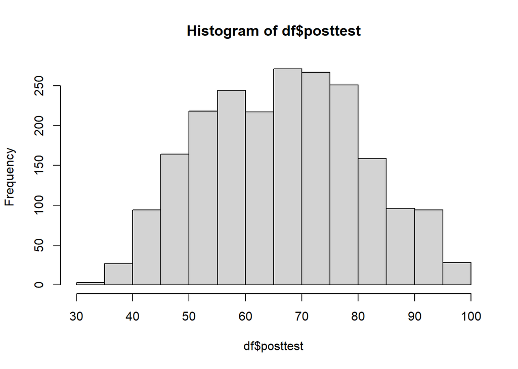

```r
hist(df$posttest)
```

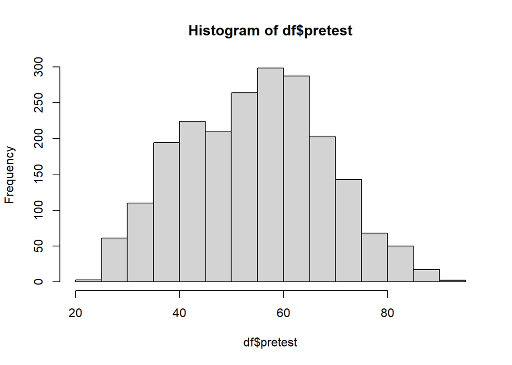

```r
hist(df$pretest)
```

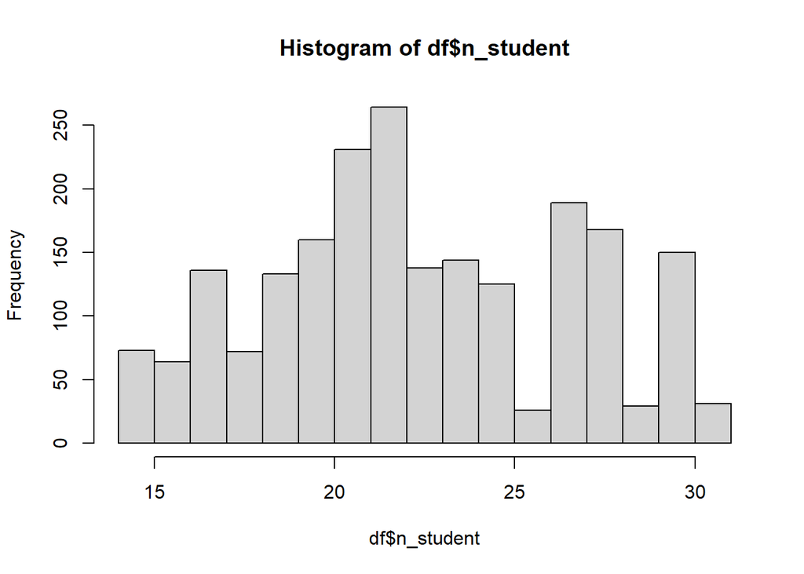

```r
hist(df$n_student)
```

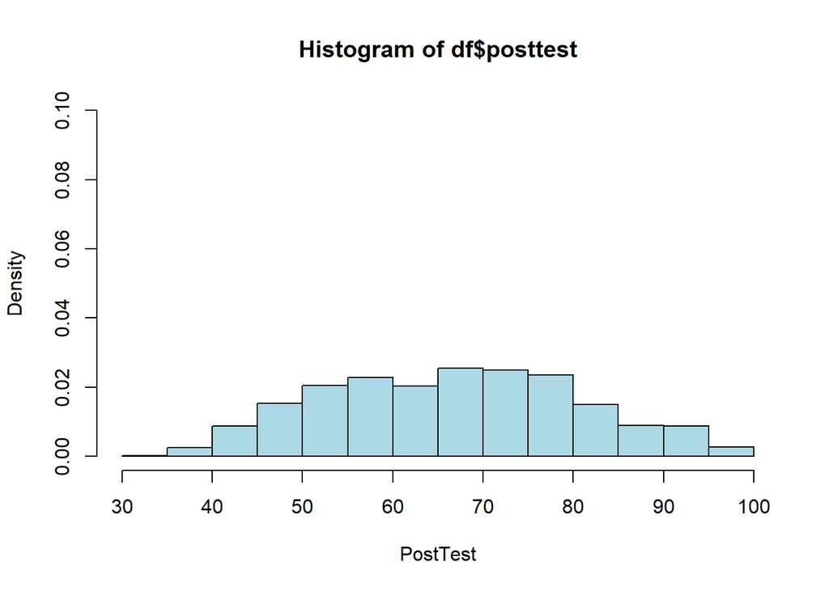

```r
hist(df$posttest, col = 'lightblue', xlab = 'PostTest', ylim = c(0, 0.1), freq = FALSE)
```

### Have seen in drawing a histogram with the hist() command that you can use freq = FALSE to force the y-axis to display the density rather than the frequency of the data. You can also call on the density function directly via the density() command.

```r
density(df$posttest)
```

```
##
## Call:
##  density.default(x = df$posttest)
##
## Data: df$posttest (2133 obs.);   Bandwidth 'bw' = 2.717
##
##        x                y
##  Min.   : 23.85   Min.   :8.700e-07
##  1st Qu.: 44.92   1st Qu.:1.854e-03
##  Median : 66.00   Median :1.060e-02
##  Mean   : 66.00   Mean   :1.185e-02
##  3rd Qu.: 87.08   3rd Qu.:2.142e-02
##  Max.   :108.15   Max.   :2.608e-02
```

### Using the Density Function to Draw a Graph

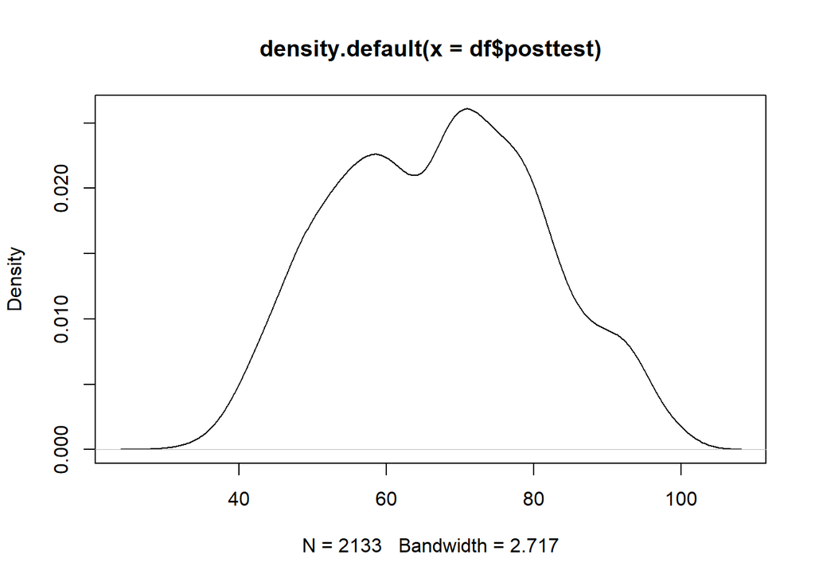

```r
plot(density(df$posttest))
```

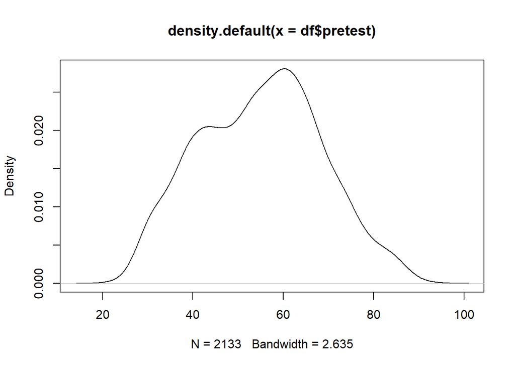

```r
plot(density(df$pretest))
```

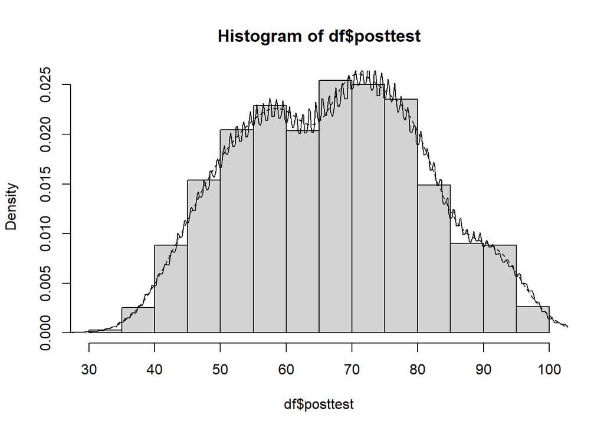

```r
hist(df$posttest, freq = F)
lines(density(df$posttest), lty = 2)
lines(density(df$posttest, k = 'rectangular'))
```

### Generates n random numbers from the normal distribution with mean of 0 and standard deviation of 1

```r
head(rnorm(df$posttest, mean = 0, sd = 1))
```

```
## [1] -1.21854490 -1.44181063  0.02108291  0.08193805  0.86910182  0.71036869
```

### Returns the probability for the quantile q

```r
head(pnorm(df$posttest, mean = 0, sd = 1))
```

```
## [1] 1 1 1 1 1 1
```

### Returns the quantile for a given probability p

```r
head(qnorm(df$posttest, mean = 0, sd = 1))
```

```
## [1] NaN NaN NaN NaN NaN NaN
```

### Gives the density function for values x

```r
head(dnorm(df$posttest, mean = 0, sd = 1))
```

```
## [1] 0 0 0 0 0 0
```

### Quantile-Quantile Plot

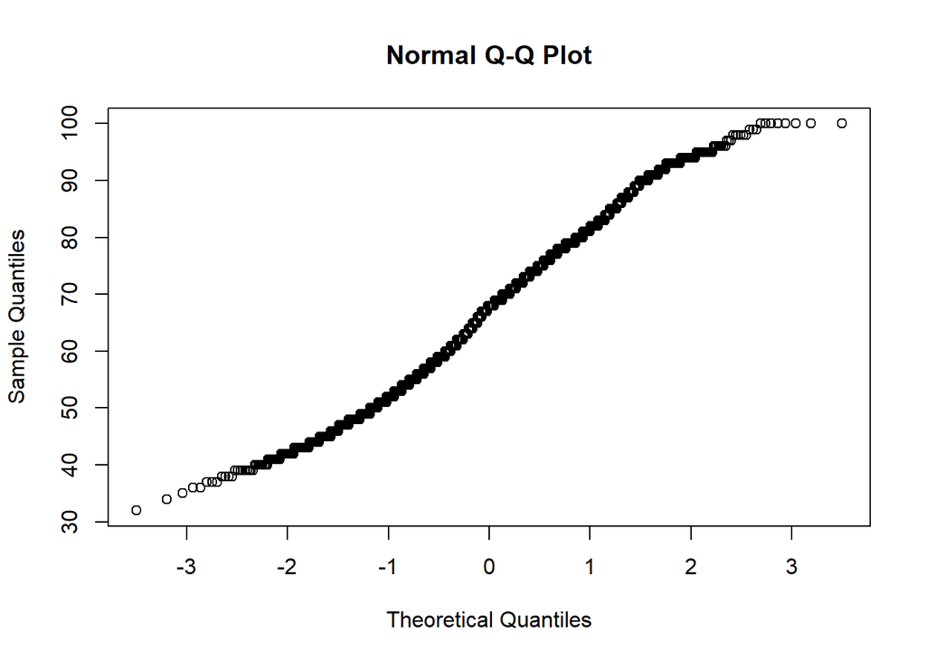

```r
qqnorm(df$posttest)
```

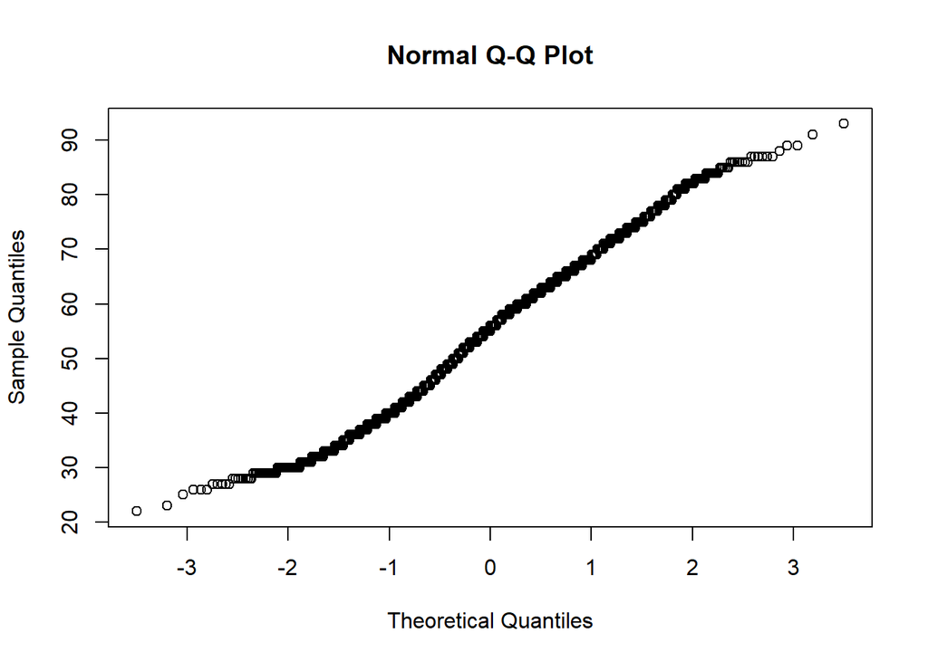

```r
qqnorm(df$pretest)
```

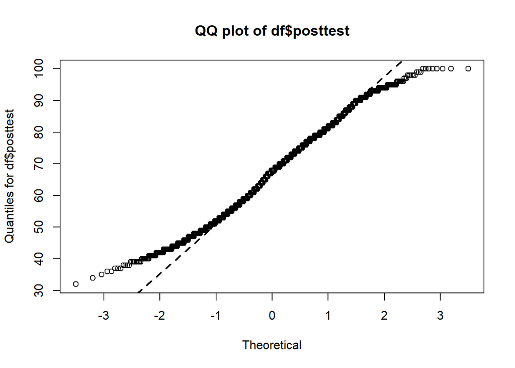

```r
qqnorm(df$posttest, main = 'QQ plot of df$posttest', xlab = 'Theoretical',
ylab = 'Quantiles for df$posttest')
qqline(df$posttest, lwd = 2, lty = 2)
```

### can also plot one distribution against another as a quantile-quantile plot using the qqplot() command.

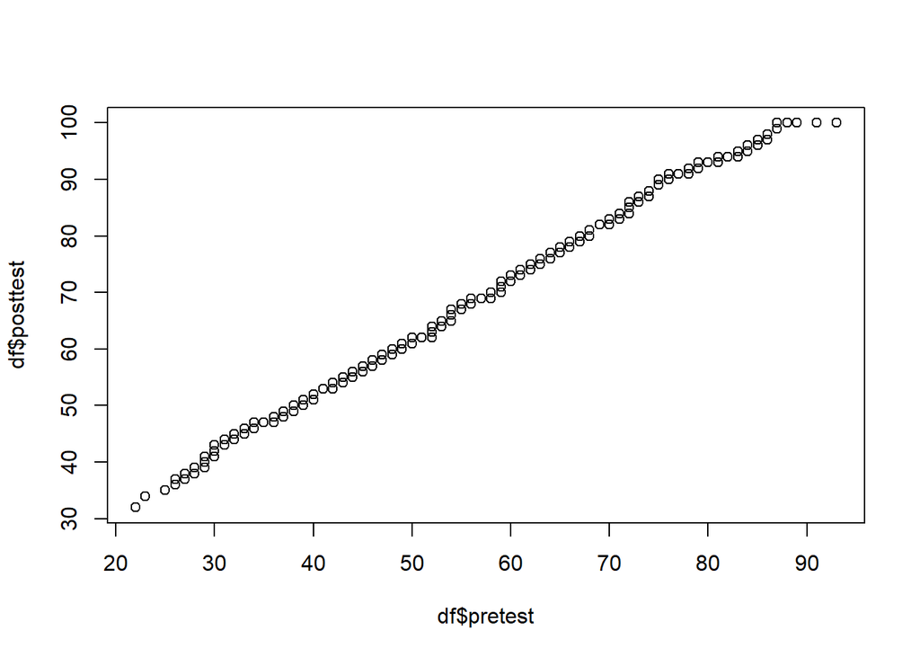

```r
qqplot(df$pretest, df$posttest)
```

### would be useful to draw a straight line on your qqplot() and you can do that using the abline() command. This command uses the properties of a straight line (that is, y = a + bx) to produce a line on an existing plot. The general form of the command is: abline(a = intercept, b = slope)

### lm(), which carries out linear modeling. This command determines the line of best fit between the x and y values in your qqp object.

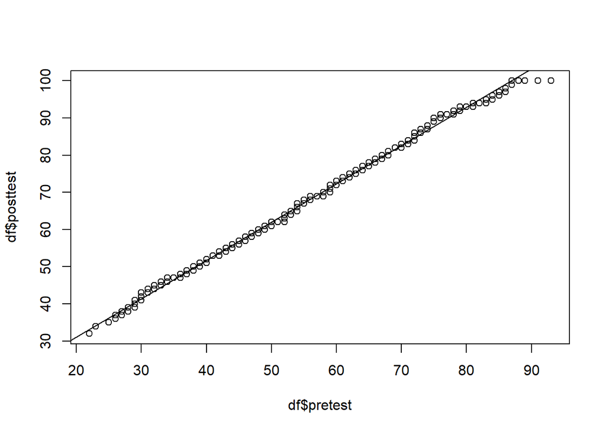

```r
qqp = qqplot(df$pretest, df$posttest)
abline(lm(qqp$y ~ qqp$x))
```

### The basic method of applying a t-test is to compare two vectors of numeric data

```r
t.test(df$pretest, df$posttest)
```

```
##
##  Welch Two Sample t-test
##
## data:  df$pretest and df$posttest
## t = -28.793, df = 4260, p-value < 2.2e-16
## alternative hypothesis: true difference in means is not equal to 0
## 95 percent confidence interval:
##  -12.97332 -11.31922
## sample estimates:
## mean of x mean of y
##  54.95593  67.10220
```

### can override the default and use the classic t-test by adding the var.equal = TRUE instruction, which forces the command to assume that the variance of the two samples is equal.

```r
t.test(df$pretest, df$posttest, var.equal = TRUE)
```

```
##
##  Two Sample t-test
##
## data:  df$pretest and df$posttest
## t = -28.793, df = 4264, p-value < 2.2e-16
## alternative hypothesis: true difference in means is not equal to 0
## 95 percent confidence interval:
##  -12.97332 -11.31922
## sample estimates:
## mean of x mean of y
##  54.95593  67.10220
```

### can also carry out a one-sample t-test. In this version you supply the name of a single vector and the mean to compare it to (this defaults to 0):

```r
t.test(df$posttest, mu = 5)
```

```
##
##  One Sample t-test
##
## data:  df$posttest
## t = 205.06, df = 2132, p-value < 2.2e-16
## alternative hypothesis: true mean is not equal to 5
## 95 percent confidence interval:
##  66.50830 67.69611
## sample estimates:
## mean of x
##   67.1022
```

### Using Directional Hypotheses

```r
t.test(df$posttest, mu = 5, alternative = 'greater')
```

```
##
##  One Sample t-test
##
## data:  df$posttest
## t = 205.06, df = 2132, p-value < 2.2e-16
## alternative hypothesis: true mean is greater than 5
## 95 percent confidence interval:
##  66.60385      Inf
## sample estimates:
## mean of x
##   67.1022
```

### Formula Syntax and Subsetting Samples in the t-Test

```r
t.test(df$posttest ~ df$school, data = df, subset = df$school %in% c('ANKYI' , 'CCAAW'))
```

```
##
##  Welch Two Sample t-test
##
## data:  df$posttest by df$school
## t = -8.4753, df = 93.982, p-value = 3.187e-13
## alternative hypothesis: true difference in means between group ANKYI and group CCAAW is not equal to 0
## 95 percent confidence interval:
##  -8.294114 -5.145582
## sample estimates:
## mean in group ANKYI mean in group CCAAW
##            71.39024            78.11009
```

### Two-Sample U-Test

```r
wilcox.test(df$pretest, df$posttest)
```

```
##
##  Wilcoxon rank sum test with continuity correction
##
## data:  df$pretest and df$posttest
## W = 1254375, p-value < 2.2e-16
## alternative hypothesis: true location shift is not equal to 0
```

### Carries out a basic correlation between x and y . If x is a matrix or data frame, y can be omitted

```r
cor(df$pretest, df$posttest)
```

```
## [1] 0.9508843
```

### Determines covariance between x and y . If x is a matrix or data frame, y can be omitted

```r
x = cov(df$pretest, df$posttest)
x
```

```
## [1] 180.3868
```

### The cov2cor() command is used to determine the correlation from a matrix of covariance in the following example:

```r
v = as.matrix(x)
cov2cor(v)
```

```
##      [,1]
## [1,]    1
```

### Significance Testing in Correlation Tests

```r
cor.test(df$pretest, df$posttest)
```

```
##
##  Pearson's product-moment correlation
##
## data:  df$pretest and df$posttest
## t = 141.81, df = 2131, p-value < 2.2e-16
## alternative hypothesis: true correlation is not equal to 0
## 95 percent confidence interval:
##  0.9466465 0.9547933
## sample estimates:
##       cor
## 0.9508843
```

### Chi-squared tests of association can be carried out using the chisq.test() command.

```r
chisq.test(df$posttest)
```

```
##
##  Chi-squared test for given probabilities
##
## data:  df$posttest
## X-squared = 6215.6, df = 2132, p-value < 2.2e-16
```

### BoxPlot’s:

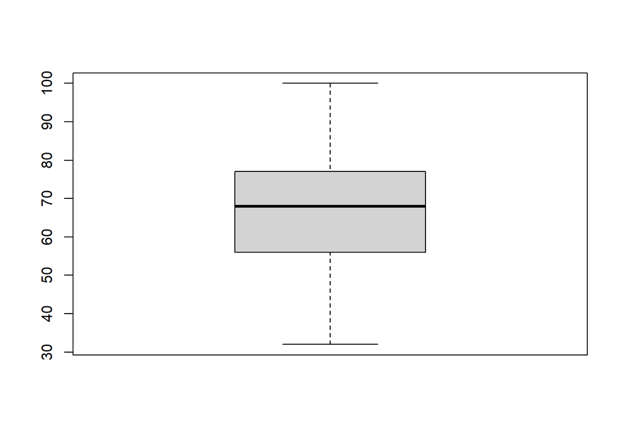

```r
boxplot(df$posttest)
```

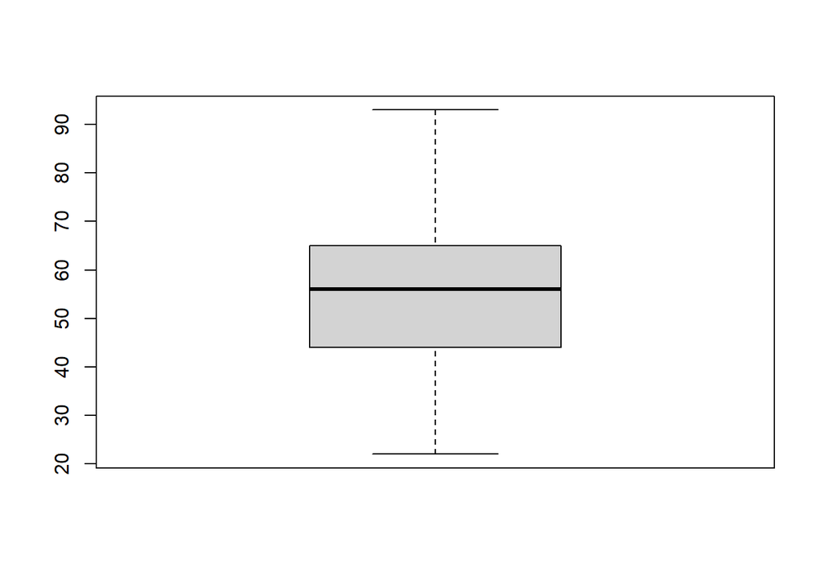

```r
boxplot(df$pretest)
```

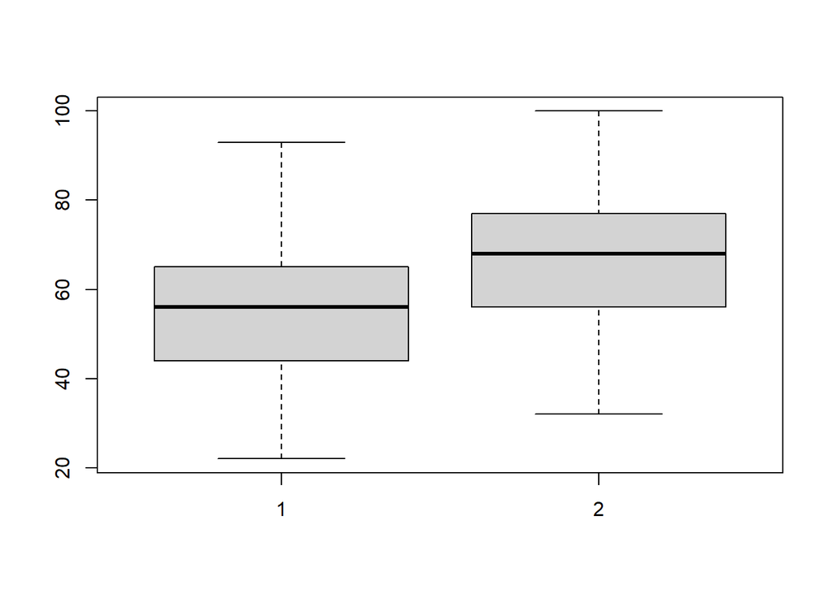

```r
boxplot(df$pretest, df$posttest)
```

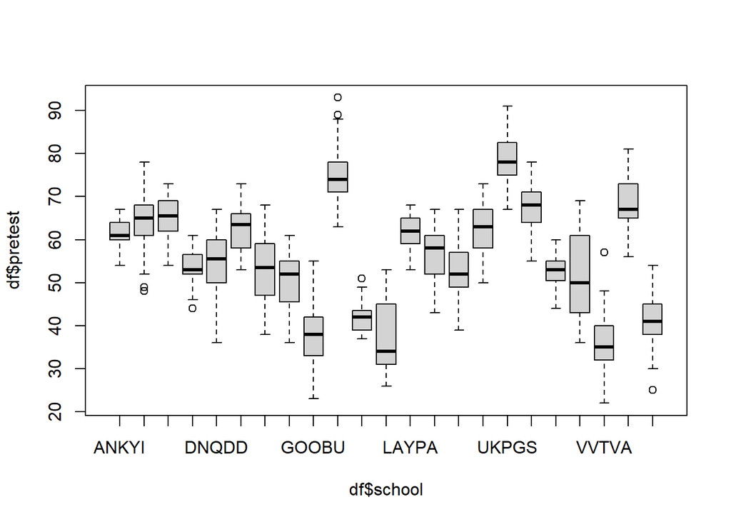

```r
boxplot(df$pretest ~ df$school, data = df)
```

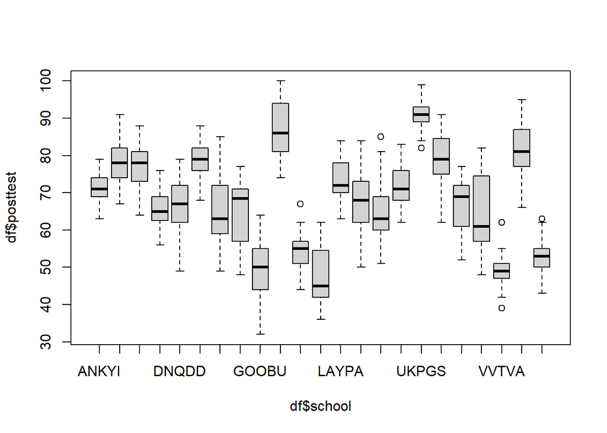

```r
boxplot(df$posttest ~ df$school, data = df)
```

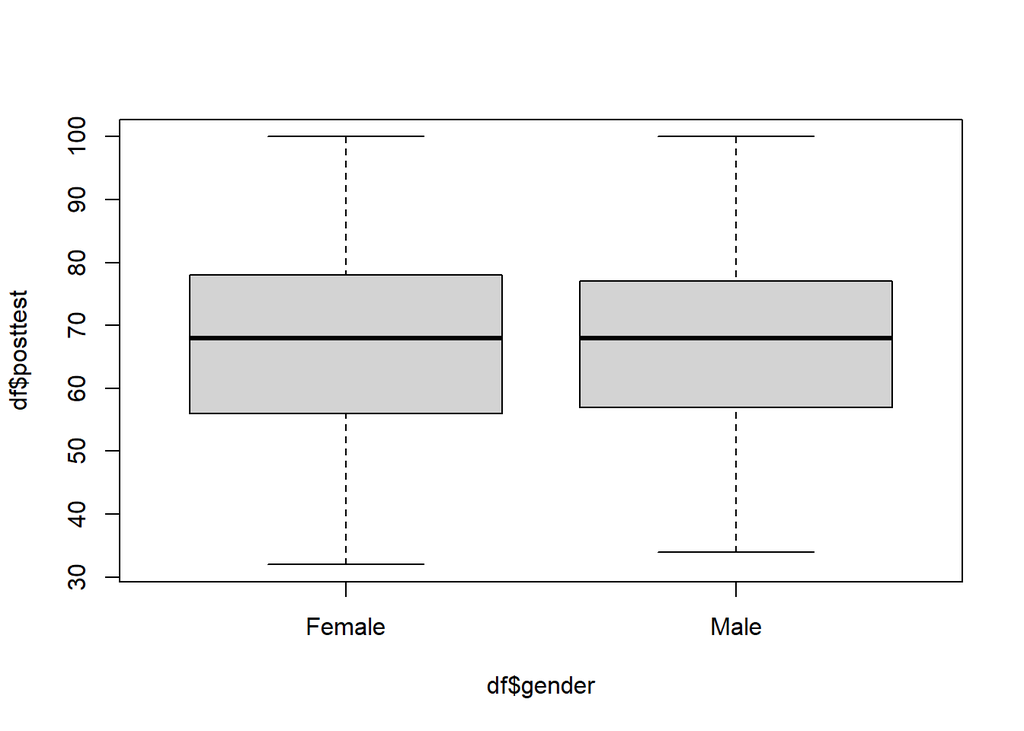

```r
boxplot(df$posttest ~ df$gender, data = df)
```

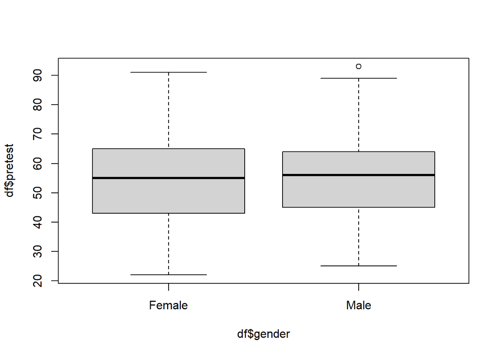

```r
boxplot(df$pretest ~ df$gender, data = df)
```

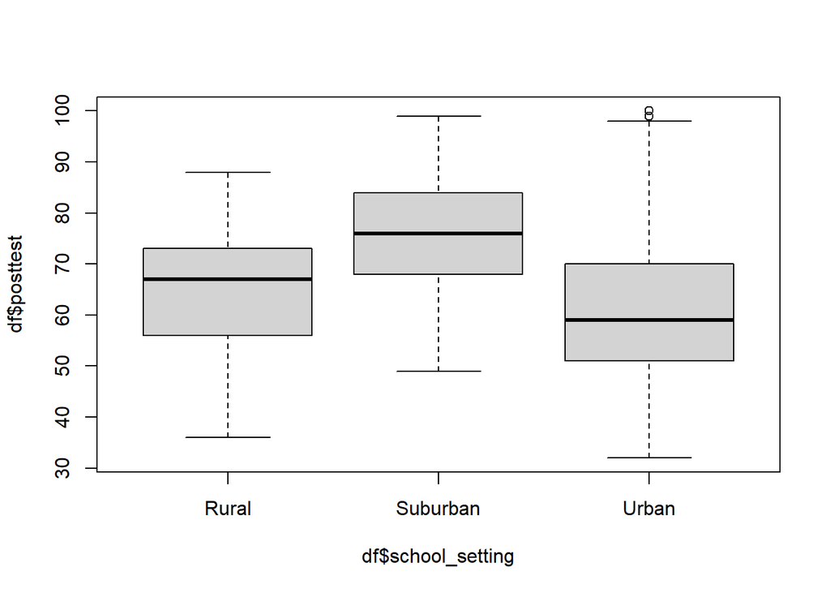

```r
boxplot(df$posttest ~ df$school_setting)
```

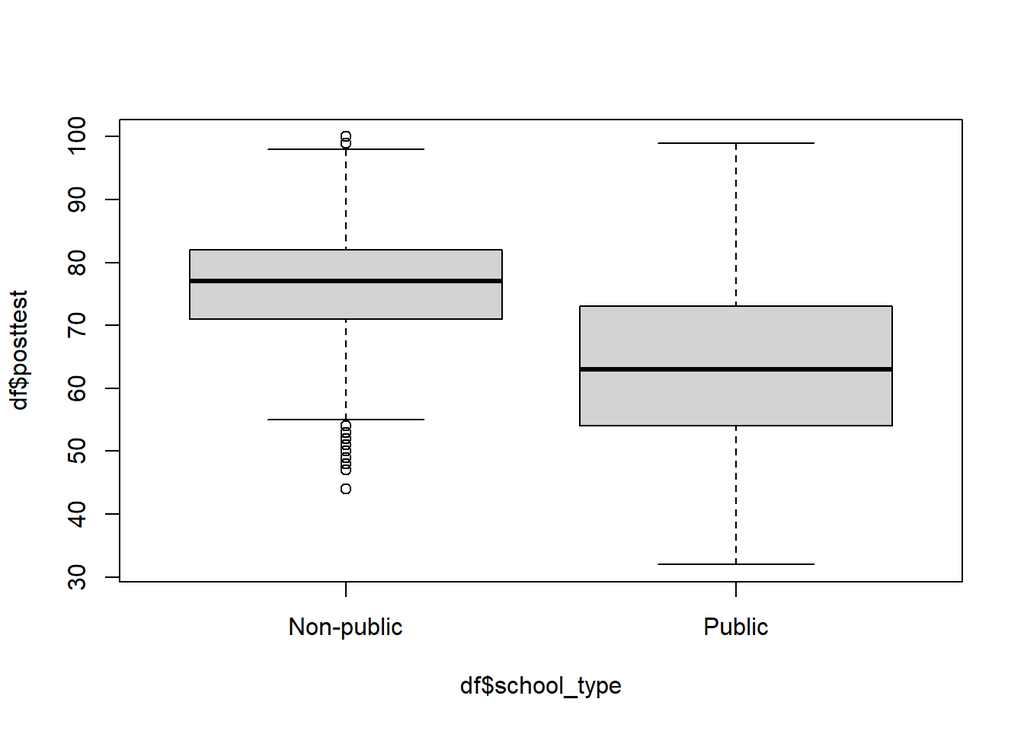

```r
boxplot(df$posttest ~ df$school_type)
```

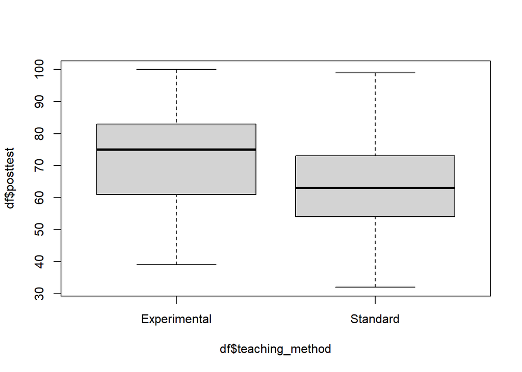

```r
boxplot(df$posttest ~ df$teaching_method)
```

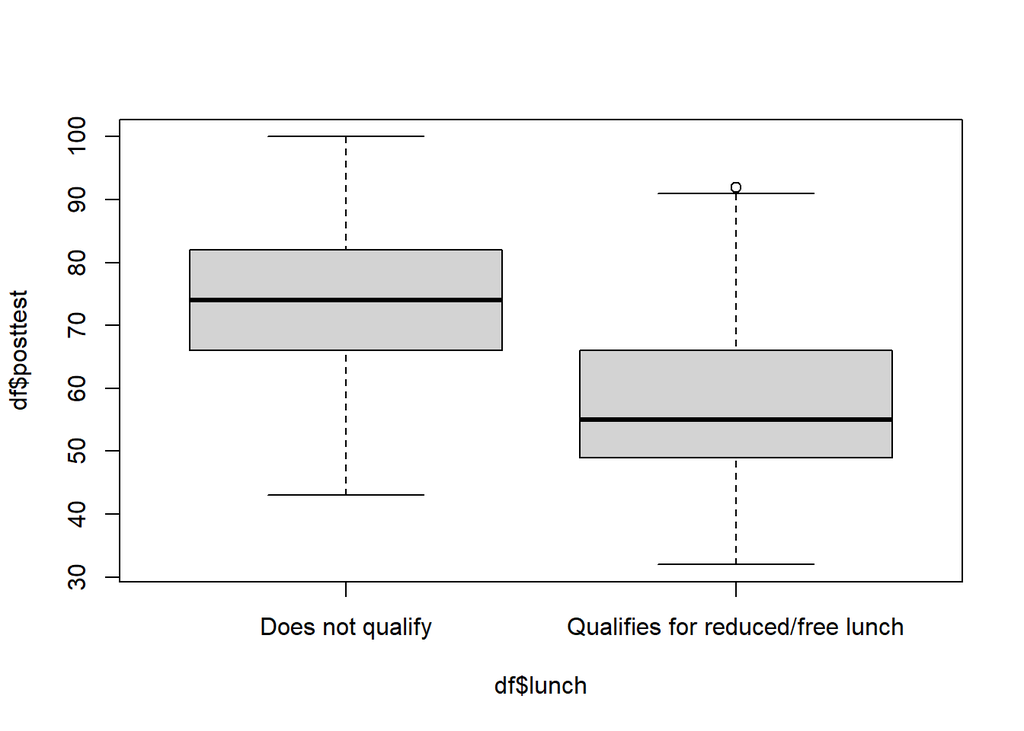

```r
boxplot(df$posttest ~ df$lunch)
```

### Horizontal Boxplots

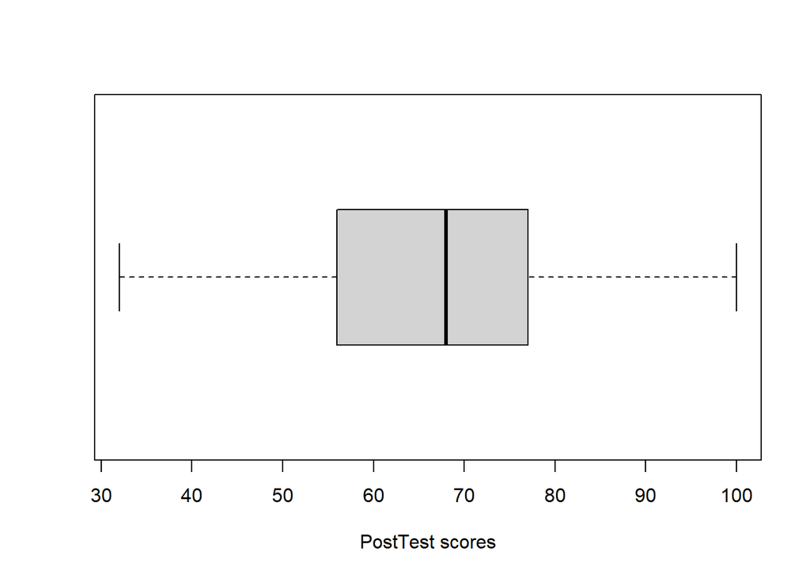

```r
boxplot(df$posttest, horizontal = T)
title(xlab = 'PostTest scores')
```

### scatter plot’s

filtering the rows by school level (ANKYI) and storing the df in temp object for ease of scatter plotting and for further usage

```r
library(dplyr)
```

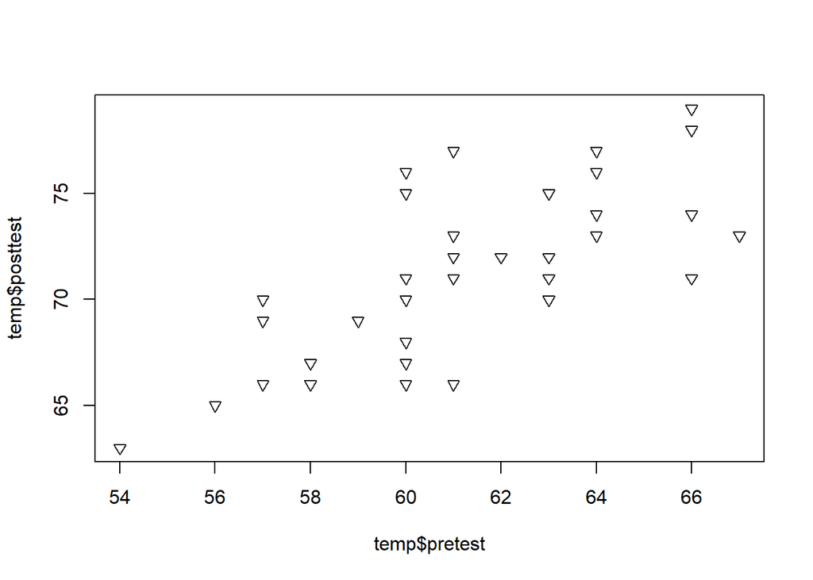

```r
temp = df %>% filter(df$school == "ANKYI")
plot(temp$pretest, temp$posttest, pch = 25)
```

### The pch = instruction refers to the plotting character, and can be specified in one of several ways. You can type an integer value and this code will be reflected in the symbol/character produced. For values from 0 to 25

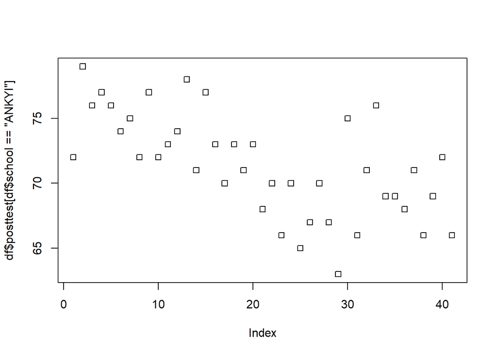

```r
with(df, plot(df$posttest[df$school == 'ANKYI'], pch = 0))
```

### with() command can be used to get the particular values based on row(level) conditions

```r
with(df, (df$posttest[df$school == 'ANKYI']))
```

```
##  [1] 72 79 76 77 76 74 75 72 77 72 73 74 78 71 77 73 70 73 71 73 68 70 66 70 65
## [26] 67 70 67 63 75 66 71 76 69 69 68 71 66 69 72 66
```

### the pairs() command takes all the columns in a data frame and creates a matrix of scatter plots.

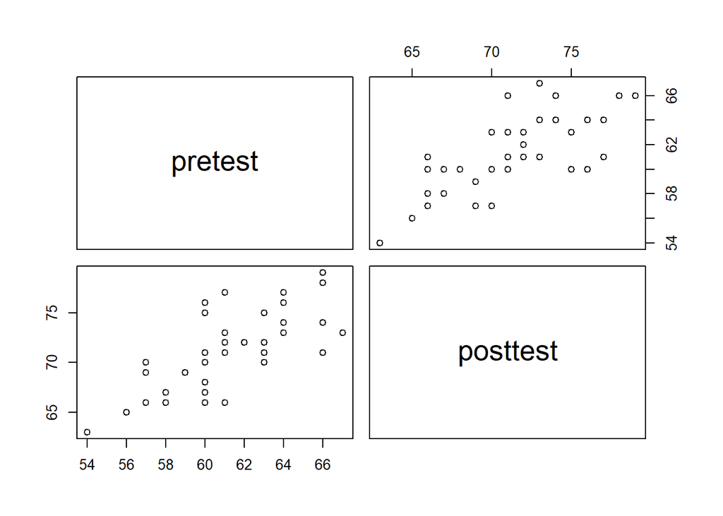

```r
pairs(~ pretest + posttest, data = temp)
```

### Line plot

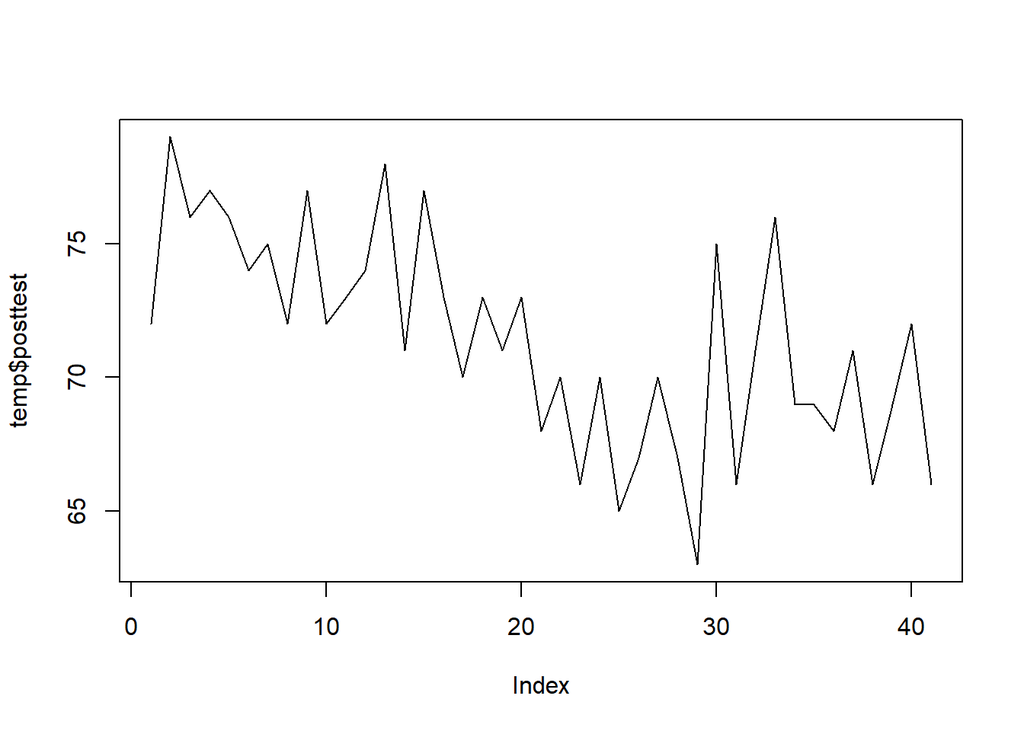

```r
plot(temp$posttest, type = 'l' )
```

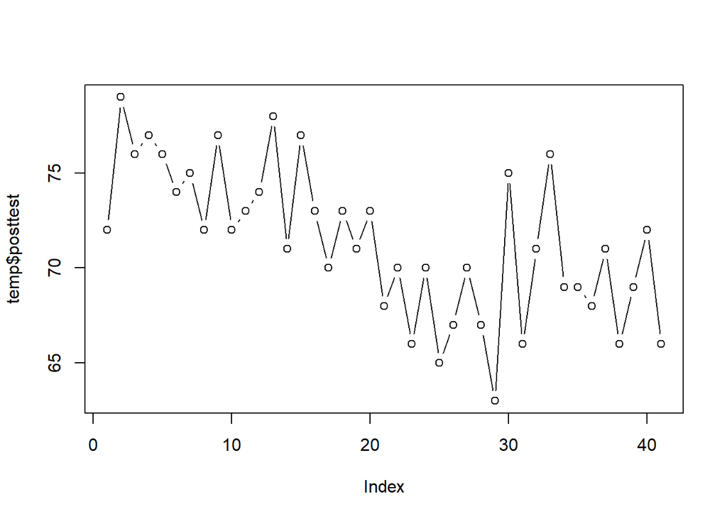

```r
plot(temp$posttest, type = 'b')
```

### Pie chart

[figure not shown]

```r
pie(temp$posttest, labels = 'PostTest score')
```

[figure not shown]

```r
pie(temp$pretest, labels = 'PreTest score')
```

### Cleveland Dot Charts

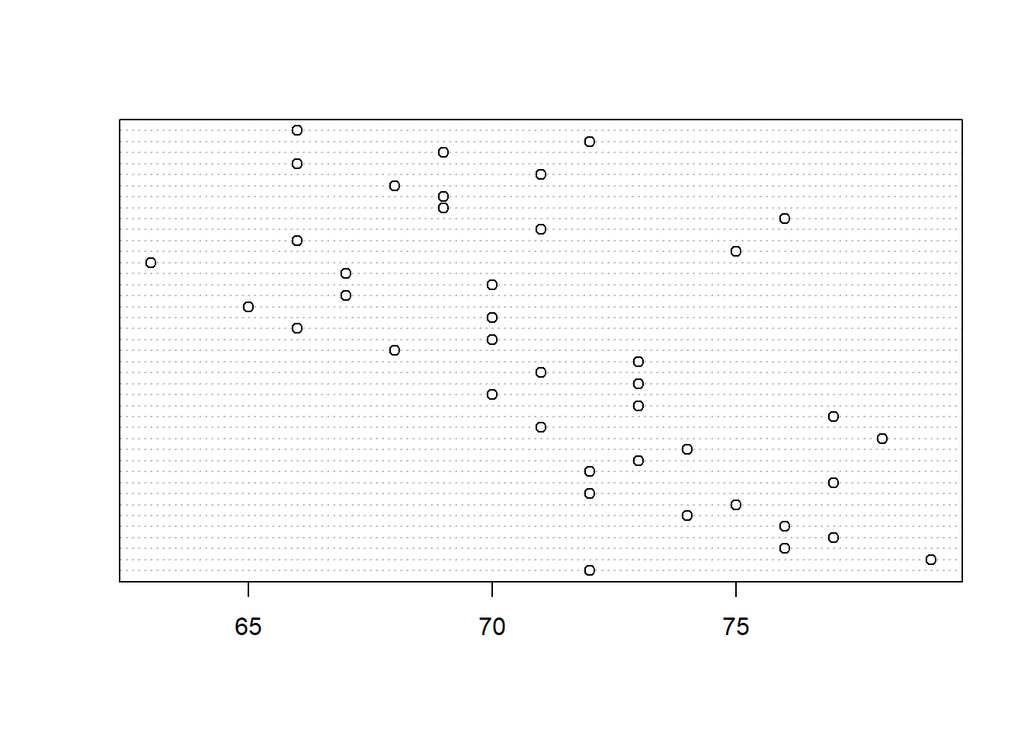

```r
dotchart(temp$posttest)
```